# Final project

Roshan

March 11, 2016

## DATA SUMMARY & METHODOLOGY

DATA OVERVIEW:

The nlsy data-set consists of nation-wide survey results of 8984 individuals who answered variious surevey questions that were categorized under 67 variables. The survey collects information about the individual personal, social, educational and occupational details. The survey respondents where aollowed to skip the questions for various reasons and if done so, the individual would have values marked from -1 to -5 in the respective columns.

INITIAL DATA CLEANING:

As the first step, mapping all negative values to NAs because the ultimate question “Is there a significant difference in income between men and women? Does the difference vary depending on other factors?” has got nothing to do with the negative values.

COLUMN CLEANING

Also deleting the columns that have more than 5000 number of missing values which is about 55% of the entire data in a column. With just 45% of valid data these columns might not have a significant effect on the Income variable.

ROW CLEANING

The data points that have 10% of values as missing decreases the quality of the data-set and the survey respondents do not really fit in to the sample that collects the necessary data to study the difference between income based on gender and for that reason removing them.

```r
# Moving NAs to the negative values
nlsy[nlsy < 0] <- NA

# Removing columns that have more than 6000 NAs
column.count <- data.frame(names(nlsy), colSums(is.na(nlsy)))
moreNA.columns <- subset(column.count, column.count$colSums.is.na.nlsy.. >= 5000)
moreNA.columns
```

```
##          names.nlsy. colSums.is.na.nlsy..
## E8043200    E8043200                 8251
## E8043400    E8043400                 8246
## R0513500    R0513500                 5481
## R0514700    R0514700                 5461
## R0514800    R0514800                 5465
## R0514900    R0514900                 5495
## R0515100    R0515100                 5473
## R0690800    R0690800                 7400
## R0691200    R0691200                 7275
## R1700500    R1700500                 5576
## R1701100    R1701100                 7792
## R4908500    R4908500                 6980
## S2011600    S2011600                 7180
## T1069100    T1069100                 7144
## T1069101    T1069101                 7155
## T1069102    T1069102                 7148
## T1069103    T1069103                 7163
## T6650100    T6650100                 7550
## T6767000    T6767000                 7436
## T7546500    T7546500                 5002
## T7546900    T7546900                 6308
## T7547000    T7547000                 8527
## T7639800    T7639800                 7831
## T7711600    T7711600                 5847
## Z9033700    Z9033700                 6518
## Z9033900    Z9033900                 6556
## Z9034100    Z9034100                 6979
```

```r
delete.columns <- moreNA.columns$names.nlsy.
nlsy <- nlsy[ , !(names(nlsy) %in% delete.columns)]
# Also deleting PUBID and SAMPLE_TYPE columns as one is just an identification number and the other does not pertain to the question. Also deleting INCOME FROM JOB IN PAST YEAR? as this variable is already covered using the TOTAL INCOME FROM WAGES AND SALARY IN PAST YEAR

nlsy$R0000100 <- NULL
nlsy$R1235800 <- NULL
nlsy$T7545400 <- NULL

nlsy.old.column.names <- names(nlsy)

# Removing rows that have more than 10% of values as NAs
nlsy <- nlsy[-manyNAs(nlsy, 0.1), ]
dim(nlsy)
```

```
## [1] 4712   37
```

Changing the column names

```r
colnames(nlsy) <- c("TOTNUM.INC", "GOOD.TEACHERS", "SAFE.AT.SCHOOL", "DPW.FAMILY.RELIGIOUS", "GENDER", "BDATE.M", "BDATE.Y", "PHY.EMO.LIMITS", "ENROLL.STAT", "HH.NET.WORTH.PRNT", "RACE", "DRUG.USE", "ORGA.RATE", "TRUST.RATE", "WEIGHT_04", "WEIGHT.RATE_04", "FAMILY.INCOME", "HH.SIZE", "HH.MEMB.UND18", "HH.MEMB.UND6", "DEG.RCVD", "MARITAL.STATUS", "RANGE.INCM.LAST.YR", "HEIGHT_FT", "HEIGHT_INCH", "WEIGHT_11", "SMOKED.DLI", "DRANK.DLI", "DRUGS.DLI", "WEIGHT.RATE_11", "DO.ABT.WEIGHT", "BUS.IND.TYPE", "DEBT.20", "EMPL.JOBS.HELD.TEEN", "EMPL.JOBS.HELD.ADULT", "JOBS.HELD.ADULT", "DEBT.30")

nlsy.new.column.names <- colnames(nlsy)
cbind(nlsy.old.column.names, nlsy.new.column.names)
```

```
##       nlsy.old.column.names nlsy.new.column.names
##  [1,] "E8043100"            "TOTNUM.INC"
##  [2,] "R0069400"            "GOOD.TEACHERS"
##  [3,] "R0070000"            "SAFE.AT.SCHOOL"
##  [4,] "R0323900"            "DPW.FAMILY.RELIGIOUS"
##  [5,] "R0536300"            "GENDER"
##  [6,] "R0536401"            "BDATE.M"
##  [7,] "R0536402"            "BDATE.Y"
##  [8,] "R0681300"            "PHY.EMO.LIMITS"
##  [9,] "R1201400"            "ENROLL.STAT"
## [10,] "R1204700"            "HH.NET.WORTH.PRNT"
## [11,] "R1482600"            "RACE"
## [12,] "R2191500"            "DRUG.USE"
## [13,] "S0920000"            "ORGA.RATE"
## [14,] "S0920700"            "TRUST.RATE"
```

[output cut: 23 more lines]

Recoding the factors levels

```r
nlsy <- transform(nlsy,
                  GENDER = as.factor(mapvalues(GENDER, c(1, 2), c("male", "female"))),
                  RACE = as.factor(mapvalues(RACE, 1:4, c("Black", "Hispanic", "Mixed", "Other"))),
                  GOOD.TEACHERS = as.factor(mapvalues(GOOD.TEACHERS, 1:4, c("Strongly Agree", "Agree", "Disagree", "Strongly Disagree"))),
                  SAFE.AT.SCHOOL = as.factor(mapvalues(SAFE.AT.SCHOOL, 1:4, c("Strongly Agree", "Agree", "Disagree", "Strongly Disagree"))),
                  BDATE.M = as.factor(mapvalues(BDATE.M, 1:12, c("Jan", "Feb", "Mar", "Apr", "May", "Jun", "Jul", "Aug", "Sep", "Oct", "Nov", "Dec"))),
                  BDATE.Y = as.factor(BDATE.Y),
                  PHY.EMO.LIMITS = as.factor(mapvalues(PHY.EMO.LIMITS, c(0, 1), c("No", "YES"))),
                  ENROLL.STAT = as.factor(mapvalues(ENROLL.STAT, 1:11, c("Not enrolled, no high school degree, no GED", "Not enrolled, GED", "Not enrolled, high school degree", "Not enrolled, some college", "Not enrolled, 2-year college graduate", "Not enrolled, 4-year college graduate", "Not enrolled, graduate degree", "Enrolled in grades 1-12, not a high school graduate", "Enrolled in a 2-year college", "Enrolled in a 4-year college", "Enrolled in a graduate program"))),
                  DRUG.USE = as.factor(mapvalues(DRUG.USE, c(1, 0), c("Yes", "No"))),
                  WEIGHT.RATE_04 = as.factor(mapvalues(WEIGHT.RATE_04, 1:5, c("VERY UNDERWEIGHT", "SLIGHTLY UNDERWEIGHT", "ABOUT THE RIGHT WEIGHT", "SLIGHTLY OVERWEIGHT", "VERY OVERWEIGHT"))),
                  DEG.RCVD = as.factor(mapvalues(DEG.RCVD, 0:7, c("None", "GED", "High school diploma", "Associate/Junior college", "Bachelor's degree", "Master's degree", "PhD", "Professional degree"))),
                  MARITAL.STATUS = as.factor(mapvalues(MARITAL.STATUS, 0:4, c("Never-married", "Married", "Separated", "Divorced", "Widowed"))),
                  SMOKED.DLI = as.factor(mapvalues(SMOKED.DLI, c(1, 0), c("Yes", "No"))),
                  DRANK.DLI = as.factor(mapvalues(DRANK.DLI, c(1, 0), c("Yes", "No"))),
                  DRUGS.DLI = as.factor(mapvalues(DRUGS.DLI, c(1, 0), c("Yes", "No"))),
                  WEIGHT.RATE_11 = as.factor(mapvalues(WEIGHT.RATE_11, 1:5, c("VERY UNDERWEIGHT", "SLIGHTLY UNDERWEIGHT", "ABOUT THE RIGHT WEIGHT", "SLIGHTLY OVERWEIGHT", "VERY OVERWEIGHT"))),
                  DO.ABT.WEIGHT = as.factor(mapvalues(DO.ABT.WEIGHT, 1:4, c("LOSE WEIGHT", "GAIN WEIGHT", "STAY THE SAME WEIGHT", "NOTHING")))
                  )

# Recode industry codes

nlsy$BUS.IND.TYPE[nlsy$BUS.IND.TYPE >= 170 & nlsy$BUS.IND.TYPE <= 290] <- "AGRICULTURE, FORESTRY AND FISHERIES"
nlsy$BUS.IND.TYPE[nlsy$BUS.IND.TYPE >= 370 & nlsy$BUS.IND.TYPE <= 490] <- "MINING"
nlsy$BUS.IND.TYPE[nlsy$BUS.IND.TYPE >= 570 & nlsy$BUS.IND.TYPE <= 690] <- "UTILITIES"
nlsy$BUS.IND.TYPE[nlsy$BUS.IND.TYPE == 770] <- "CONSTRUCTION"
nlsy$BUS.IND.TYPE[nlsy$BUS.IND.TYPE >= 1070 & nlsy$BUS.IND.TYPE <= 3990] <- "MANUFACTURING"
nlsy$BUS.IND.TYPE[nlsy$BUS.IND.TYPE >= 4070 & nlsy$BUS.IND.TYPE <= 4590] <- "WHOLESALE TRADE"
nlsy$BUS.IND.TYPE[nlsy$BUS.IND.TYPE >= 4670 & nlsy$BUS.IND.TYPE <= 5790] <- "RETAIL TRADE"
nlsy$BUS.IND.TYPE[nlsy$BUS.IND.TYPE == 5890] <- "ARTS, ENTERTAINMENT AND RECREATION SERVICES"
nlsy$BUS.IND.TYPE[nlsy$BUS.IND.TYPE >= 6070 & nlsy$BUS.IND.TYPE <= 6390] <- "TRANSPORTATION AND WAREHOUSING"
nlsy$BUS.IND.TYPE[nlsy$BUS.IND.TYPE >= 6470 & nlsy$BUS.IND.TYPE <= 6780] <- "INFORMATION AND COMMUNICATION"
nlsy$BUS.IND.TYPE[nlsy$BUS.IND.TYPE >= 6870 & nlsy$BUS.IND.TYPE <= 7190] <- "FINANCE, INSURANCE, AND REAL ESTATE"
nlsy$BUS.IND.TYPE[nlsy$BUS.IND.TYPE >= 7270 & nlsy$BUS.IND.TYPE <= 7790] <- "PROFESSIONAL AND RELATED SERVICES"
nlsy$BUS.IND.TYPE[nlsy$BUS.IND.TYPE >= 7860 & nlsy$BUS.IND.TYPE <= 8470] <- "EDUCATIONAL, HEALTH, AND SOCIAL SERVICES"
nlsy$BUS.IND.TYPE[nlsy$BUS.IND.TYPE >= 8560 & nlsy$BUS.IND.TYPE <= 8690] <- "ENTERTAINMENT, ACCOMODATIONS, AND FOOD SERVICES"
nlsy$BUS.IND.TYPE[nlsy$BUS.IND.TYPE >= 8770 & nlsy$BUS.IND.TYPE <= 9290] <- "OTHER SERVICES"
nlsy$BUS.IND.TYPE[nlsy$BUS.IND.TYPE >= 9370 & nlsy$BUS.IND.TYPE <= 9590] <- "PUBLIC ADMINISTRATION"
nlsy$BUS.IND.TYPE[nlsy$BUS.IND.TYPE >= 9670 & nlsy$BUS.IND.TYPE <= 9890] <- "ACTIVE DUTY MILITARY"
nlsy$BUS.IND.TYPE[nlsy$BUS.IND.TYPE >= 9950 & nlsy$BUS.IND.TYPE <= 9990] <- "ACS SPECIAL CODES"
nlsy$BUS.IND.TYPE <- as.factor(nlsy$BUS.IND.TYPE)

str(nlsy)
```

```
## 'data.frame':    4712 obs. of  37 variables:
##  $ TOTNUM.INC          : int  0 0 0 0 0 0 0 0 0 1 ...
##  $ GOOD.TEACHERS       : Factor w/ 4 levels "Agree","Disagree",..: 1 1 1 3 1 1 1 1 2 4 ...
##  $ SAFE.AT.SCHOOL      : Factor w/ 4 levels "Agree","Disagree",..: 1 2 1 3 1 1 1 2 2 4 ...
##  $ DPW.FAMILY.RELIGIOUS: int  3 0 3 1 0 NA 1 3 0 0 ...
##  $ GENDER              : Factor w/ 2 levels "female","male": 2 1 2 2 1 2 1 2 2 2 ...
##  $ BDATE.M             : Factor w/ 12 levels "Apr","Aug","Dec",..: 6 12 11 11 7 11 5 4 4 1 ...
##  $ BDATE.Y             : Factor w/ 5 levels "1980","1981",..: 3 4 3 3 3 2 4 3 3 5 ...
##  $ PHY.EMO.LIMITS      : Factor w/ 2 levels "No","YES": NA 1 1 1 1 1 NA 1 1 1 ...
##  $ ENROLL.STAT         : Factor w/ 3 levels "Enrolled in grades 1-12, not a high school graduate",..: 1 1 1 1 1 1 1 1 1 1 ...
##  $ HH.NET.WORTH.PRNT   : int  NA 10200 NA NA 17500 17500 NA 17500 3750 3750 ...
##  $ RACE                : Factor w/ 4 levels "Black","Hispanic",..: 2 2 2 4 2 2 2 2 1 1 ...
##  $ DRUG.USE            : Factor w/ 2 levels "No","Yes": 1 1 1 1 1 1 1 1 1 1 ...
##  $ ORGA.RATE           : int  2 3 2 4 3 NA 4 1 1 2 ...
##  $ TRUST.RATE          : int  5 5 5 5 3 NA 5 5 5 5 ...
```

[output cut: 23 more lines]

Checking summary statistics, correlation among numeric variables and some more cleaning

```r
kable(summary(nlsy))
```

|  | TOTNUM.INC | GOOD.TEACHERS | SAFE.AT.SCHOOL | DPW.FAMILY.RELIGIOUS | GENDER | BDATE.M | BDATE.Y | PHY.EMO.LIMITS | ENROLL.STAT | HH.NET.WORTH.PRNT | RACE | DRUG.USE | ORGA.RATE | TRUST.RATE | WEIGHT_04 | WEIGHT.RATE_04 | FAMILY.INCOME | HH.SIZE | HH.MEMB.UND18 | HH.MEMB.UND6 | DEG.RCVD | MARITAL.STATUS | RANGE.INCM.LAST.YR | HEIGHT_FT | HEIGHT_INCH | WEIGHT_11 | SMOKED.DLI | DRANK.DLI | DRUGS.DLI | … |
| --- | --- | --- | --- | --- | --- | --- | --- | --- | --- | --- | --- | --- | --- | --- | --- | --- | --- | --- | --- | --- | --- | --- | --- | --- | --- | --- | --- | --- | --- | --- |
|  | Min. :0.0000 | Agree :3259 | Agree :2538 | Min. :0.000 | female:2352 | Sep : 447 | 1980: 464 | No :4143 | Enrolled in grades 1-12, not a high school graduate:4655 | Min. : 0 | Black :1125 | No :4377 | Min. :1.000 | Min. :1.000 | Min. : 15.0 | ABOUT THE RIGHT WEIGHT:2308 | Min. : 0 | Min. : 1.000 | Min. :0.000 | Min. :0.0000 | High school diploma :2078 | Divorced : 290 | Min. : 0 | Min. :1.000 | Min. : 0.000 | Min. : 1.0 | No :3004 | No :1032 | No :4569 | … |
|  | 1st Qu.:0.0000 | Disagree : 431 | Disagree : 500 | 1st Qu.:0.000 | male :2360 | Nov : 419 | 1981: 512 | YES : 288 | Not enrolled, high school degree : 1 | 1st Qu.: 9719 | Hispanic: 989 | Yes : 248 | 1st Qu.:2.000 | 1st Qu.:4.000 | 1st Qu.:138.0 | SLIGHTLY OVERWEIGHT :1507 | 1st Qu.: 30570 | 1st Qu.: 2.000 | 1st Qu.:0.000 | 1st Qu.:0.0000 | Bachelor’s degree :1105 | Married :1740 | 1st Qu.: 18000 | 1st Qu.:5.000 | 1st Qu.: 2.000 | 1st Qu.:150.0 | Yes :1702 | Yes :3664 | Yes : 137 | … |
|  | Median :0.0000 | Strongly Agree : 915 | Strongly Agree :1536 | Median :1.000 | NA | Jan : 418 | 1982:1273 | NA’s: 281 | Not enrolled, no high school degree, no GED : 56 | Median : 45000 | Mixed : 45 | NA’s: 87 | Median :2.000 | Median :5.000 | Median :160.0 | SLIGHTLY UNDERWEIGHT : 431 | Median : 55000 | Median : 3.000 | Median :1.000 | Median :0.0000 | GED : 473 | Never-married:2615 | Median : 30000 | Median :5.000 | Median : 5.000 | Median :175.0 | NA’s: 6 | NA’s: 16 | NA’s: 6 | … |
|  | Mean :0.1067 | Strongly Disagree: 106 | Strongly Disagree: 136 | Mean :1.647 | NA | Oct : 410 | 1983:1301 | NA | NA | Mean :101074 | Other :2553 | NA | Mean :2.409 | Mean :4.404 | Mean :168.9 | VERY OVERWEIGHT : 330 | Mean : 68023 | Mean : 3.197 | Mean :1.008 | Mean :0.5303 | Associate/Junior college: 384 | Separated : 58 | Mean : 34083 | Mean :5.186 | Mean : 5.282 | Mean :182.9 | NA | NA | NA | … |
|  | 3rd Qu.:0.0000 | NA’s : 1 | NA’s : 2 | 3rd Qu.:2.000 | NA | Aug : 407 | 1984:1162 | NA | NA | 3rd Qu.:128500 | NA | NA | 3rd Qu.:3.000 | 3rd Qu.:5.000 | 3rd Qu.:190.0 | VERY UNDERWEIGHT : 38 | 3rd Qu.: 86750 | 3rd Qu.: 4.000 | 3rd Qu.:2.000 | 3rd Qu.:1.0000 | None : 346 | Widowed : 5 | 3rd Qu.: 45000 | 3rd Qu.:5.000 | 3rd Qu.: 8.000 | 3rd Qu.:210.0 | NA | NA | NA | … |
|  | Max. :9.0000 | NA | NA | Max. :7.000 | NA | Jul : 389 | NA | NA | NA | Max. :600000 | NA | NA | Max. :5.000 | Max. :5.000 | Max. :450.0 | NA’s : 98 | Max. :316618 | Max. :15.000 | Max. :9.000 | Max. :5.0000 | (Other) : 304 | NA’s : 4 | Max. :146002 | Max. :7.000 | Max. :12.000 | Max. :472.0 | NA | NA | NA | … |
|  | NA | NA | NA | NA’s :984 | NA | (Other):2222 | NA | NA | NA | NA’s :915 | NA | NA | NA’s :1035 | NA’s :1033 | NA’s :141 | NA | NA’s :310 | NA | NA’s :5 | NA’s :5 | NA’s : 22 | NA | NA’s :784 | NA’s :12 | NA’s :10 | NA’s :40 | NA | NA | NA | … |

```r
# Selecting only the numeric columns for correlation
nlsy.num <- nlsy[c(1, 4, 10, 13:15, 17:20, 23:26, 33:37)]
kable(cor(nlsy.num, use="pairwise.complete.obs"))
```

|  | TOTNUM.INC | DPW.FAMILY.RELIGIOUS | HH.NET.WORTH.PRNT | ORGA.RATE | TRUST.RATE | WEIGHT_04 | FAMILY.INCOME | HH.SIZE | HH.MEMB.UND18 | HH.MEMB.UND6 | RANGE.INCM.LAST.YR | HEIGHT_FT | HEIGHT_INCH | WEIGHT_11 | DEBT.20 | EMPL.JOBS.HELD.TEEN | EMPL.JOBS.HELD.ADULT | JOBS.HELD.ADULT | DEBT.30 |
| --- | --- | --- | --- | --- | --- | --- | --- | --- | --- | --- | --- | --- | --- | --- | --- | --- | --- | --- | --- |
| TOTNUM.INC | 1.0000000 | -0.0290205 | -0.0506043 | 0.0269833 | -0.0294886 | 0.0090946 | -0.0806746 | -0.0136326 | 0.0006475 | -0.0036530 | -0.0891647 | 0.0356919 | 0.0193371 | 0.0090923 | -0.0290473 | 0.0445711 | 0.0707947 | 0.0791342 | -0.0099358 |
| DPW.FAMILY.RELIGIOUS | -0.0290205 | 1.0000000 | -0.0352668 | -0.0610075 | 0.0267229 | -0.0011739 | -0.0328115 | 0.0699261 | 0.0557017 | 0.0691814 | -0.0217538 | -0.0290903 | 0.0059017 | -0.0121337 | -0.0024173 | -0.0521026 | -0.0216024 | -0.0169449 | -0.0267853 |
| HH.NET.WORTH.PRNT | -0.0506043 | -0.0352668 | 1.0000000 | 0.0149779 | 0.0230985 | -0.0812710 | 0.2317580 | -0.1891824 | -0.2107764 | -0.1168366 | 0.2443789 | 0.0602418 | 0.0316496 | -0.0966095 | -0.0332564 | 0.0115278 | 0.0113040 | 0.0240200 | 0.0128170 |
| ORGA.RATE | 0.0269833 | -0.0610075 | 0.0149779 | 1.0000000 | -0.0960658 | 0.0934006 | -0.0467802 | -0.0048891 | -0.0306494 | -0.0361712 | -0.0576172 | 0.0388408 | 0.0350670 | 0.0964289 | -0.0317837 | 0.0063611 | 0.0300120 | 0.0384862 | -0.0031178 |
| TRUST.RATE | -0.0294886 | 0.0267229 | 0.0230985 | -0.0960658 | 1.0000000 | -0.0161143 | 0.0316416 | -0.0240398 | 0.0020142 | -0.0050814 | 0.0490848 | -0.0342323 | -0.0013763 | -0.0327320 | 0.0483390 | 0.0075931 | 0.0078044 | 0.0083938 | 0.0424234 |
| WEIGHT_04 | 0.0090946 | -0.0011739 | -0.0812710 | 0.0934006 | -0.0161143 | 1.0000000 | -0.0370608 | -0.0116920 | -0.0275713 | -0.0222355 | 0.0458102 | 0.3257163 | 0.0681652 | 0.8549280 | 0.0105373 | 0.0145535 | -0.0099111 | -0.0122432 | 0.0020265 |
| FAMILY.INCOME | -0.0806746 | -0.0328115 | 0.2317580 | -0.0467802 | 0.0316416 | -0.0370608 | 1.0000000 | -0.0051939 | -0.1131470 | -0.0561261 | 0.4827757 | 0.0317338 | -0.0009879 | -0.0432082 | 0.0717454 | 0.0424705 | -0.0536265 | -0.0480802 | 0.1108370 |
| HH.SIZE | -0.0136326 | 0.0699261 | -0.1891824 | -0.0048891 | -0.0240398 | -0.0116920 | -0.0051939 | 1.0000000 | 0.8016694 | 0.5818726 | -0.1597381 | -0.1010996 | -0.0148145 | 0.0100560 | 0.0096793 | -0.0268511 | -0.0747825 | -0.0725771 | -0.0418067 |
| HH.MEMB.UND18 | 0.0006475 | 0.0557017 | -0.2107764 | -0.0306494 | 0.0020142 | -0.0275713 | -0.1131470 | 0.8016694 | 1.0000000 | 0.7333837 | -0.1252597 | -0.1201038 | -0.0390149 | -0.0053255 | 0.0168286 | 0.0142240 | -0.0829078 | -0.0826099 | -0.0490670 |
| HH.MEMB.UND6 | -0.0036530 | 0.0691814 | -0.1168366 | -0.0361712 | -0.0050814 | -0.0222355 | -0.0561261 | 0.5818726 | 0.7333837 | 1.0000000 | -0.0395979 | -0.0674763 | -0.0160468 | 0.0189562 | 0.0217487 | 0.0362830 | -0.0738293 | -0.0733032 | -0.0066915 |
| RANGE.INCM.LAST.YR | -0.0891647 | -0.0217538 | 0.2443789 | -0.0576172 | 0.0490848 | 0.0458102 | 0.4827757 | -0.1597381 | -0.1252597 | -0.0395979 | 1.0000000 | 0.1253451 | 0.0206513 | 0.0243373 | 0.0467412 | 0.0208972 | -0.1741824 | -0.1731345 | 0.0817583 |
| HEIGHT_FT | 0.0356919 | -0.0290903 | 0.0602418 | 0.0388408 | -0.0342323 | 0.3257163 | 0.0317338 | -0.1010996 | -0.1201038 | -0.0674763 | 0.1253451 | 1.0000000 | -0.5446259 | 0.3234132 | 0.0038699 | 0.0542179 | 0.0088225 | 0.0130863 | -0.0086162 |
| HEIGHT_INCH | 0.0193371 | 0.0059017 | 0.0316496 | 0.0350670 | -0.0013763 | 0.0681652 | -0.0009879 | -0.0148145 | -0.0390149 | -0.0160468 | 0.0206513 | -0.5446259 | 1.0000000 | 0.0493507 | -0.0131524 | -0.0243443 | -0.0127111 | -0.0077105 | -0.0028314 |
| WEIGHT_11 | 0.0090923 | -0.0121337 | -0.0966095 | 0.0964289 | -0.0327320 | 0.8549280 | -0.0432082 | 0.0100560 | -0.0053255 | 0.0189562 | 0.0243373 | 0.3234132 | 0.0493507 | 1.0000000 | 0.0050064 | 0.0081947 | -0.0217406 | -0.0221661 | 0.0088053 |
| DEBT.20 | -0.0290473 | -0.0024173 | -0.0332564 | -0.0317837 | 0.0483390 | 0.0105373 | 0.0717454 | 0.0096793 | 0.0168286 | 0.0217487 | 0.0467412 | 0.0038699 | -0.0131524 | 0.0050064 | 1.0000000 | 0.0869569 | -0.0072198 | -0.0059372 | 0.1332186 |
| EMPL.JOBS.HELD.TEEN | 0.0445711 | -0.0521026 | 0.0115278 | 0.0063611 | 0.0075931 | 0.0145535 | 0.0424705 | -0.0268511 | 0.0142240 | 0.0362830 | 0.0208972 | 0.0542179 | -0.0243443 | 0.0081947 | 0.0869569 | 1.0000000 | 0.2995295 | 0.3068989 | 0.0788986 |
| EMPL.JOBS.HELD.ADULT | 0.0707947 | -0.0216024 | 0.0113040 | 0.0300120 | 0.0078044 | -0.0099111 | -0.0536265 | -0.0747825 | -0.0829078 | -0.0738293 | -0.1741824 | 0.0088225 | -0.0127111 | -0.0217406 | -0.0072198 | 0.2995295 | 1.0000000 | 0.9730685 | 0.0663070 |
| JOBS.HELD.ADULT | 0.0791342 | -0.0169449 | 0.0240200 | 0.0384862 | 0.0083938 | -0.0122432 | -0.0480802 | -0.0725771 | -0.0826099 | -0.0733032 | -0.1731345 | 0.0130863 | -0.0077105 | -0.0221661 | -0.0059372 | 0.3068989 | 0.9730685 | 1.0000000 | 0.0673551 |
| DEBT.30 | -0.0099358 | -0.0267853 | 0.0128170 | -0.0031178 | 0.0424234 | 0.0020265 | 0.1108370 | -0.0418067 | -0.0490670 | -0.0066915 | 0.0817583 | -0.0086162 | -0.0028314 | 0.0088053 | 0.1332186 | 0.0788986 | 0.0663070 | 0.0673551 | 1.0000000 |

```r
# Since JOBS.HELD.ADULT & EMPL.JOBS.HELD.ADULT are highly correlated, moving NULL to EMPL.JOBS.HELD.ADULT.
nlsy$EMPL.JOBS.HELD.ADULT <- NULL
```

Check for normalisation by plotting histogram for each of the variables

```r
# Checking normality for numeric variable

mean(nlsy$TOTNUM.INC, na.rm = TRUE)
```

```
## [1] 0.1067487
```

```r
sd(nlsy$TOTNUM.INC, na.rm = TRUE)
```

```
## [1] 0.5070728
```

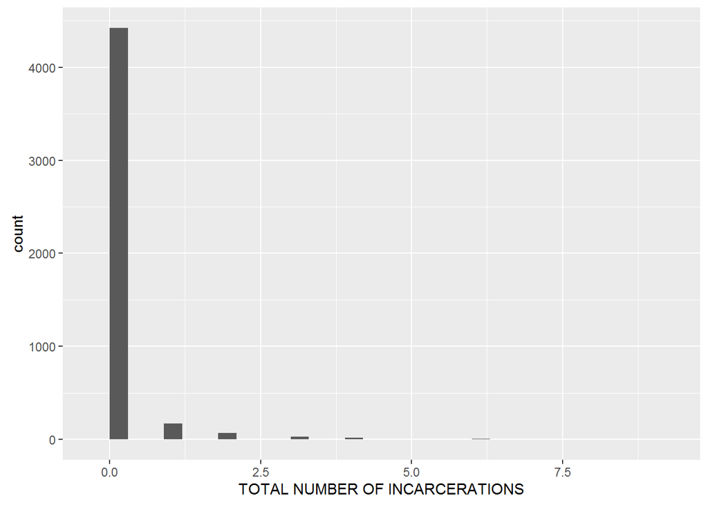

```r
# Skewed to the right as most of the row values are 0.
qplot(na.omit(nlsy$TOTNUM.INC), xlab = "TOTAL NUMBER OF INCARCERATIONS", geom="histogram")
```

```r
mean(nlsy$DPW.FAMILY.RELIGIOUS, na.rm = TRUE)
```

```
## [1] 1.647532
```

```r
sd(nlsy$DPW.FAMILY.RELIGIOUS, na.rm = TRUE)
```

```
## [1] 2.031999
```

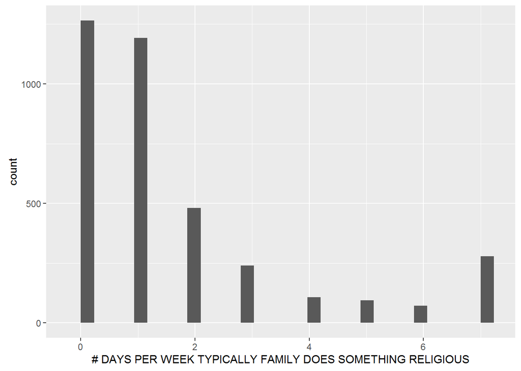

```r
# Skewed to the right as most of the row values are 0 and 1.
qplot(na.omit(nlsy$DPW.FAMILY.RELIGIOUS), xlab = "# DAYS PER WEEK TYPICALLY FAMILY DOES SOMETHING RELIGIOUS", geom="histogram")
```

```r
mean(nlsy$HH.NET.WORTH.PRNT, na.rm = TRUE)
```

```
## [1] 101074.3
```

```r
sd(nlsy$HH.NET.WORTH.PRNT, na.rm = TRUE)
```

```
## [1] 140595.8
```

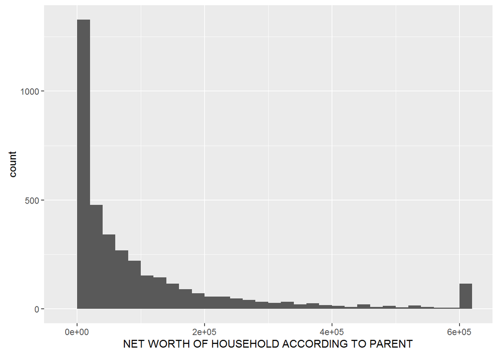

```r
# Right skewed
qplot(na.omit(nlsy$HH.NET.WORTH.PRNT), xlab = "NET WORTH OF HOUSEHOLD ACCORDING TO PARENT", geom="histogram")
```

```r
mean(nlsy$ORGA.RATE, na.rm = TRUE)
```

```
## [1] 2.408757
```

```r
sd(nlsy$ORGA.RATE, na.rm = TRUE)
```

```
## [1] 1.007944
```

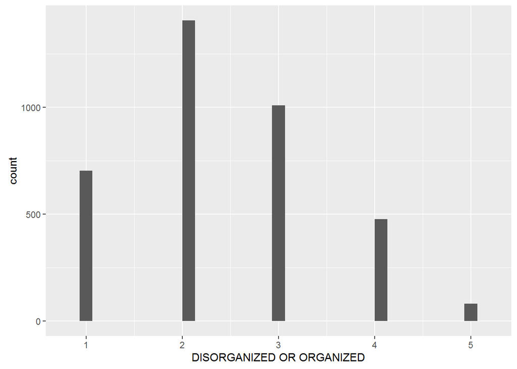

```r
# Normally distributed.
qplot(na.omit(nlsy$ORGA.RATE), xlab = "DISORGANIZED OR ORGANIZED", geom="histogram")
```

```r
mean(nlsy$TRUST.RATE, na.rm = TRUE)
```

```
## [1] 4.403642
```

```r
sd(nlsy$TRUST.RATE, na.rm = TRUE)
```

```
## [1] 0.9376412
```

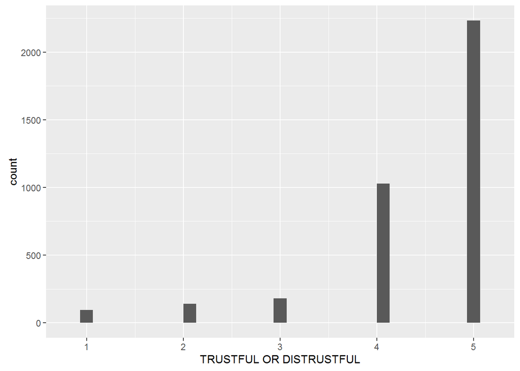

```r
# Skewed to left as most of them answered that they were trustful
qplot(na.omit(nlsy$TRUST.RATE), xlab = "TRUSTFUL OR DISTRUSTFUL", geom="histogram")
```

```r
mean(nlsy$WEIGHT_04, na.rm = TRUE)
```

```
## [1] 168.8836
```

```r
sd(nlsy$WEIGHT_04, na.rm = TRUE)
```

```
## [1] 42.87813
```

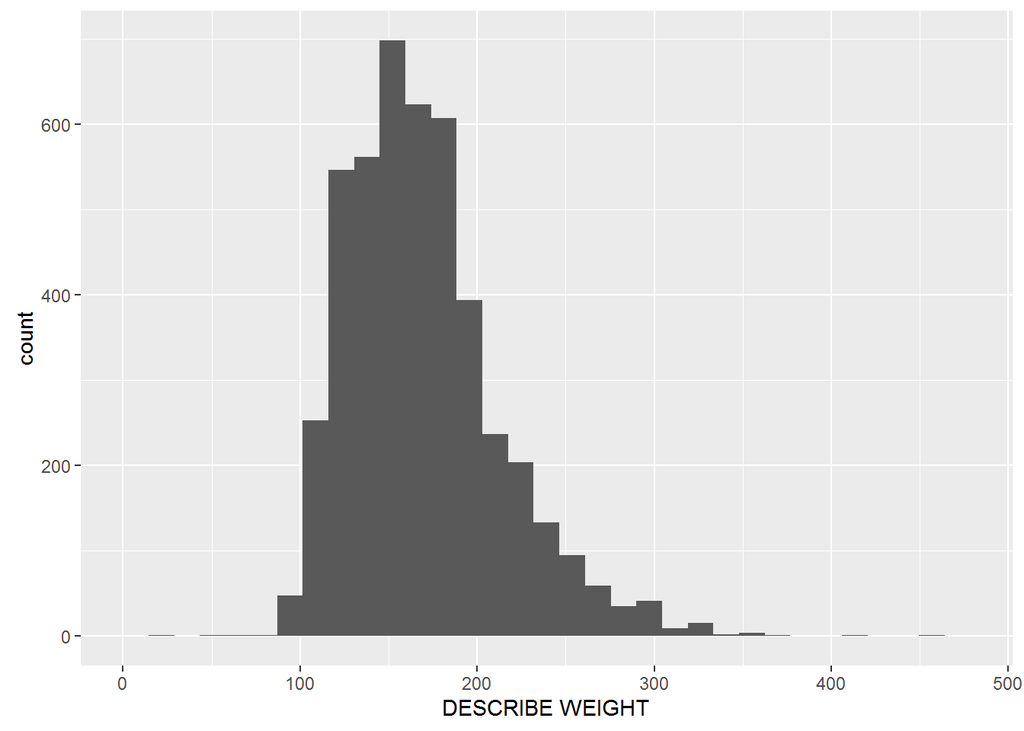

```r
# normally distributed.
qplot(na.omit(nlsy$WEIGHT_04), xlab = "DESCRIBE WEIGHT", geom="histogram")
```

```r
mean(nlsy$FAMILY.INCOME, na.rm = TRUE)
```

```
## [1] 68023.18
```

```r
sd(nlsy$FAMILY.INCOME, na.rm = TRUE)
```

```
## [1] 58872.99
```

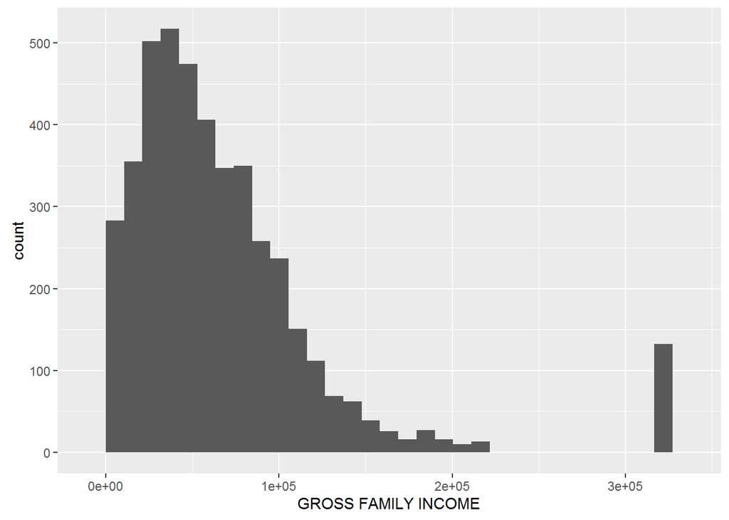

```r
# Skewed to right
qplot(na.omit(nlsy$FAMILY.INCOME), xlab = "GROSS FAMILY INCOME", geom="histogram")
```

```r
mean(nlsy$HH.SIZE, na.rm = TRUE)
```

```
## [1] 3.197156
```

```r
sd(nlsy$HH.SIZE, na.rm = TRUE)
```

```
## [1] 1.601968
```

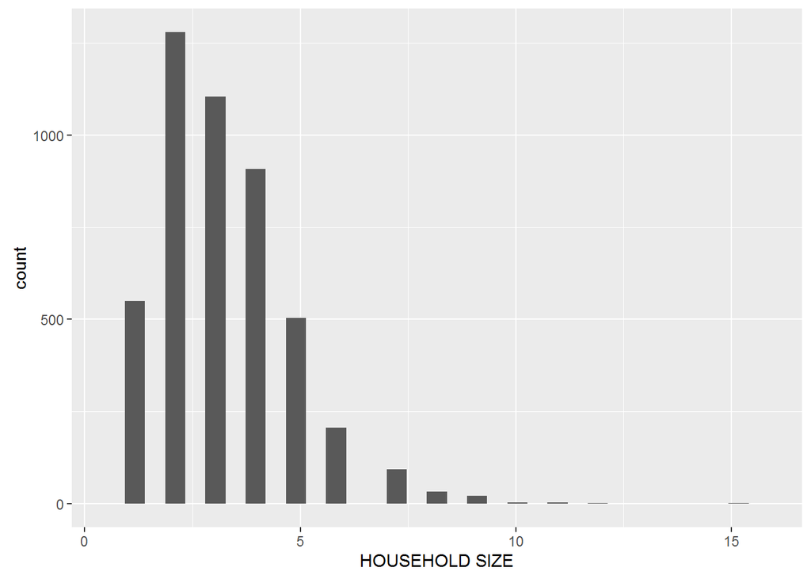

```r
# moderately normally distributed.
qplot(na.omit(nlsy$HH.SIZE), xlab = "HOUSEHOLD SIZE", geom="histogram")
```

```r
mean(nlsy$HH.MEMB.UND18, na.rm = TRUE)
```

```
## [1] 1.008073
```

```r
sd(nlsy$HH.MEMB.UND18, na.rm = TRUE)
```

```
## [1] 1.25446
```

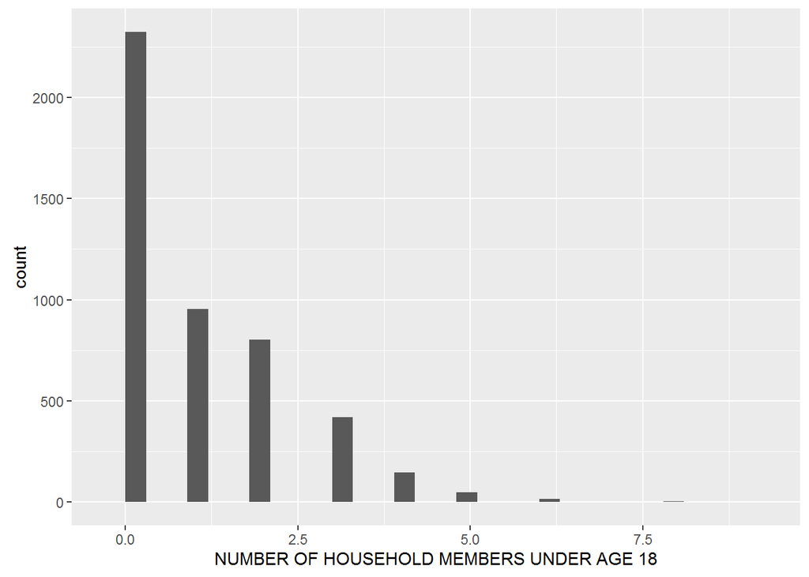

```r
# Skewed to right as there were mostly 0 household members under age 18 in a family
qplot(na.omit(nlsy$HH.MEMB.UND18), xlab = "NUMBER OF HOUSEHOLD MEMBERS UNDER AGE 18", geom="histogram")
```

```r
mean(nlsy$HH.MEMB.UND6, na.rm = TRUE)
```

```
## [1] 0.5302741
```

```r
sd(nlsy$HH.MEMB.UND6, na.rm = TRUE)
```

```
## [1] 0.7714128
```

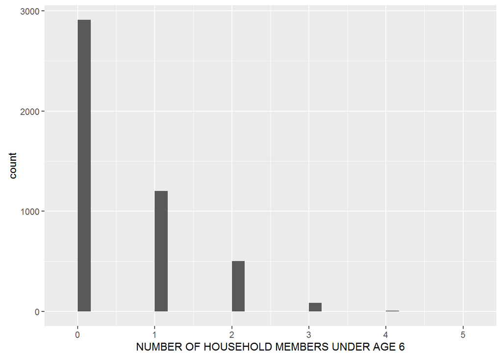

```r
# Skewed to right as there were mostly 0 household members under age 6 in a family
qplot(na.omit(nlsy$HH.MEMB.UND6), xlab = "NUMBER OF HOUSEHOLD MEMBERS UNDER AGE 6", geom="histogram")
```

```r
mean(nlsy$RANGE.INCM.LAST.YR, na.rm = TRUE)
```

```
## [1] 34083.19
```

```r
sd(nlsy$RANGE.INCM.LAST.YR, na.rm = TRUE)
```

```
## [1] 25254.38
```

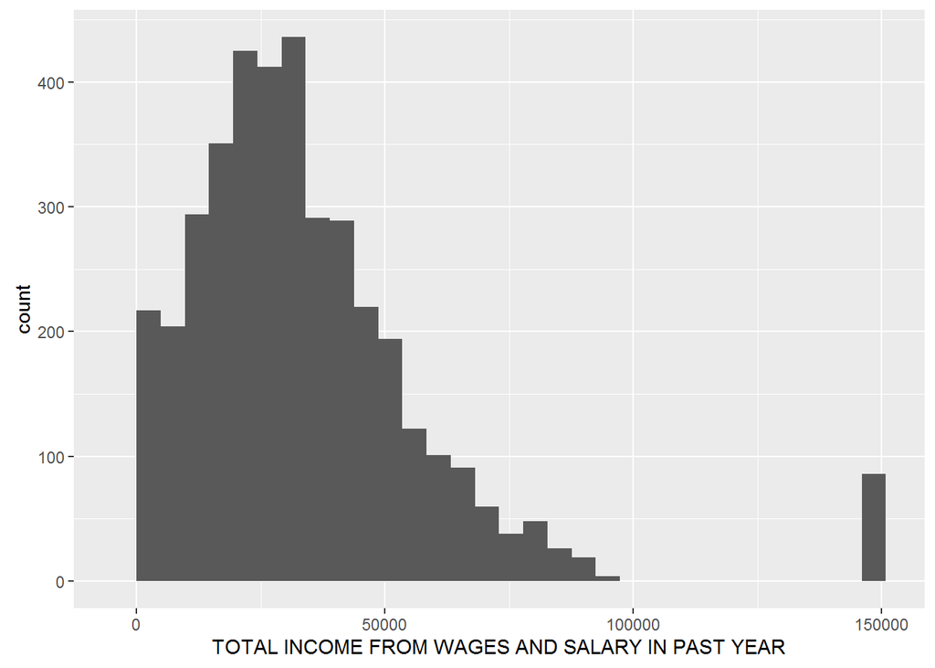

```r
# Normally distributed
qplot(na.omit(nlsy$RANGE.INCM.LAST.YR), xlab = "TOTAL INCOME FROM WAGES AND SALARY IN PAST YEAR", geom="histogram")
```

```r
mean(nlsy$HEIGHT_FT, na.rm = TRUE)
```

```
## [1] 5.185745
```

```r
sd(nlsy$HEIGHT_FT, na.rm = TRUE)
```

```
## [1] 0.4412361
```

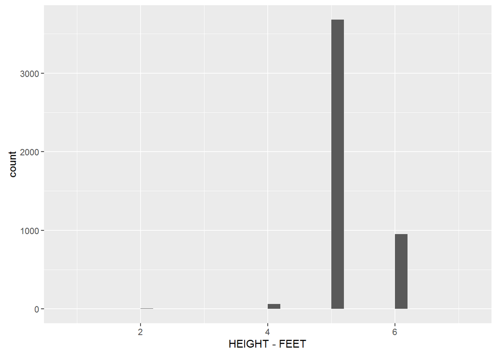

```r
# moderately normally distributed
qplot(na.omit(nlsy$HEIGHT_FT), xlab = "HEIGHT - FEET", geom="histogram")
```

```r
mean(nlsy$HEIGHT_INCH, na.rm = TRUE)
```

```
## [1] 5.282008
```

```r
sd(nlsy$HEIGHT_INCH, na.rm = TRUE)
```

```
## [1] 3.405829
```

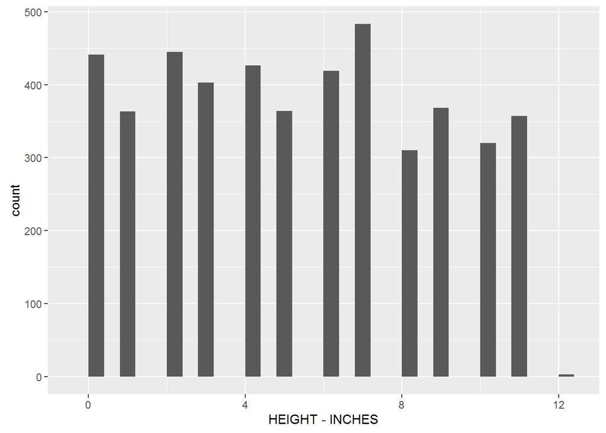

```r
# Not normally distributed
qplot(na.omit(nlsy$HEIGHT_INCH), xlab = "HEIGHT - INCHES", geom="histogram")
```

```r
mean(nlsy$WEIGHT_11, na.rm = TRUE)
```

```
## [1] 182.9202
```

```r
sd(nlsy$WEIGHT_11, na.rm = TRUE)
```

```
## [1] 48.99424
```

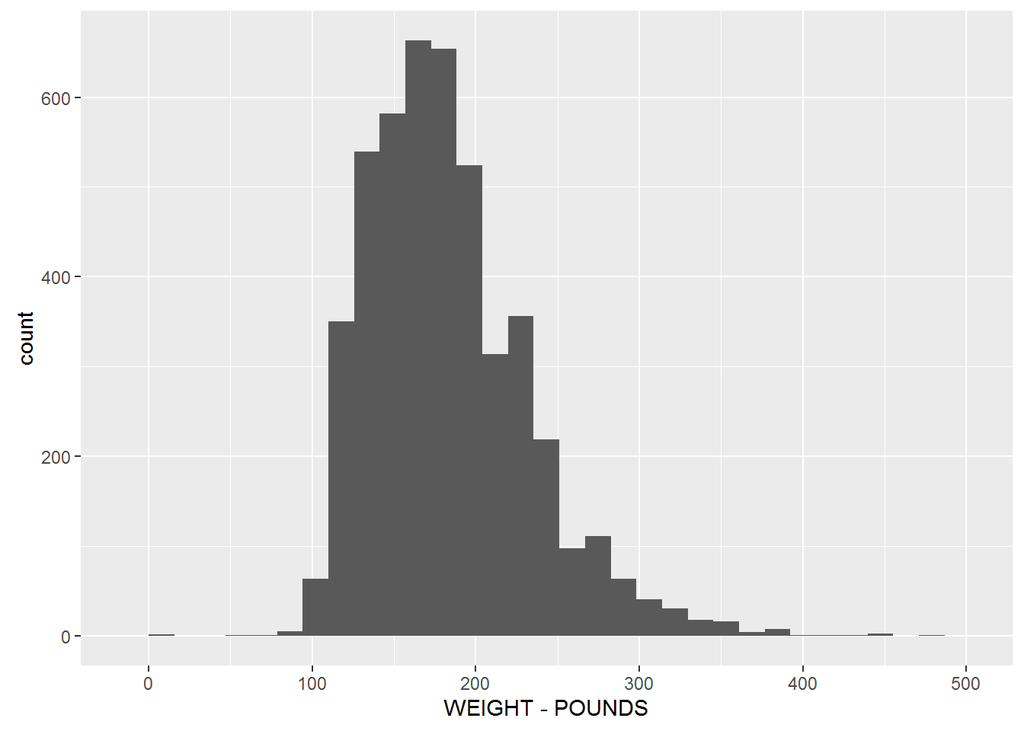

```r
# normally distributed
qplot(na.omit(nlsy$WEIGHT_11), xlab = "WEIGHT - POUNDS", geom="histogram")
```

```r
mean(nlsy$DEBT.20, na.rm = TRUE)
```

```
## [1] 3639.869
```

```r
sd(nlsy$DEBT.20, na.rm = TRUE)
```

```
## [1] 7850.905
```

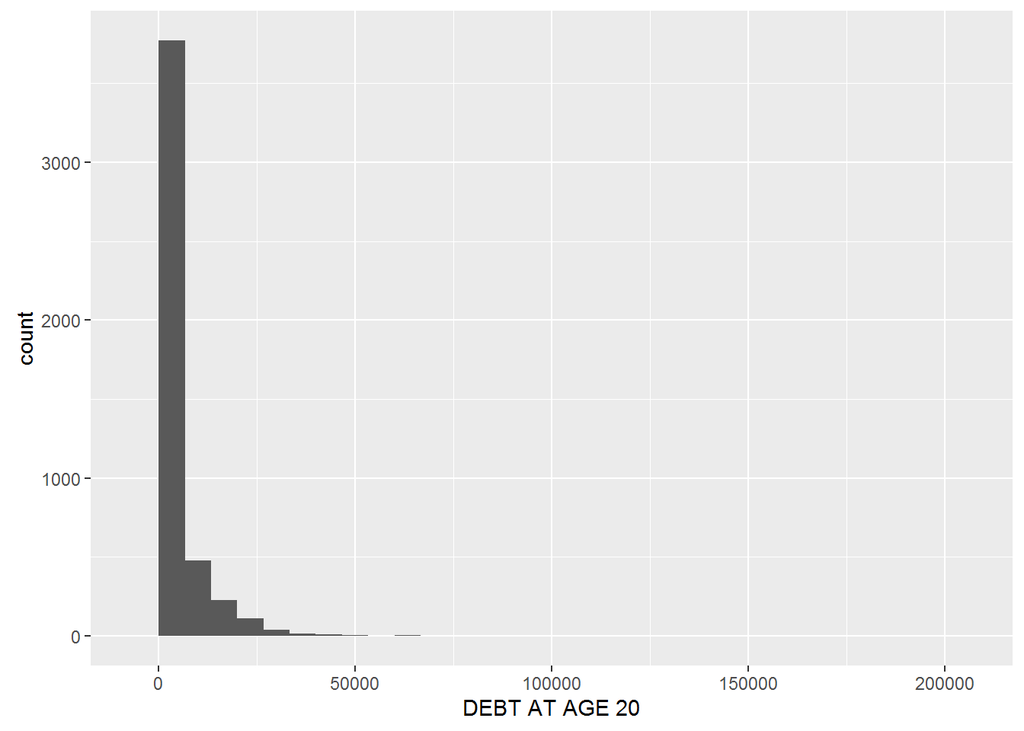

```r
# Skewed to right as most of them had 0 debt.
qplot(na.omit(nlsy$DEBT.20), xlab = "DEBT AT AGE 20", geom="histogram")
```

```r
mean(nlsy$EMPL.JOBS.HELD.TEEN, na.rm = TRUE)
```

```
## [1] 4.052028
```

```r
sd(nlsy$EMPL.JOBS.HELD.TEEN, na.rm = TRUE)
```

```
## [1] 2.347211
```